# Titanic data exploration markdown

# 5 Task II code chunks 2

## 5.1 Age

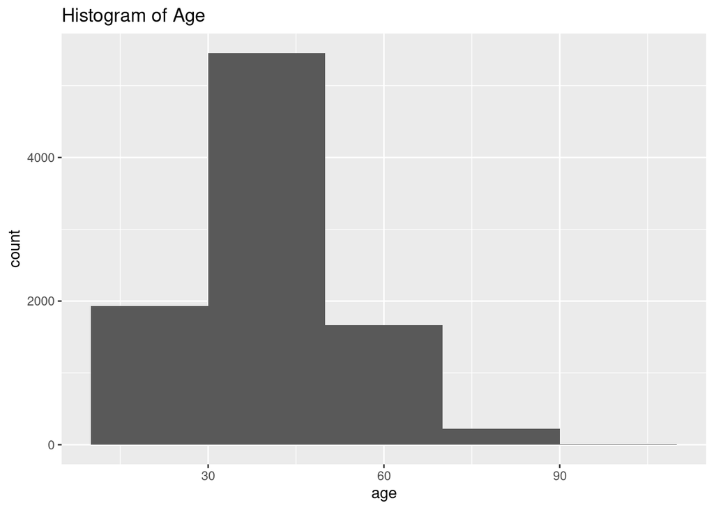

```r
# A histogram
institution %>% ggplot() +
  geom_histogram(aes(x=age),binwidth = 20) +
  ggtitle("Histogram of Age")
```

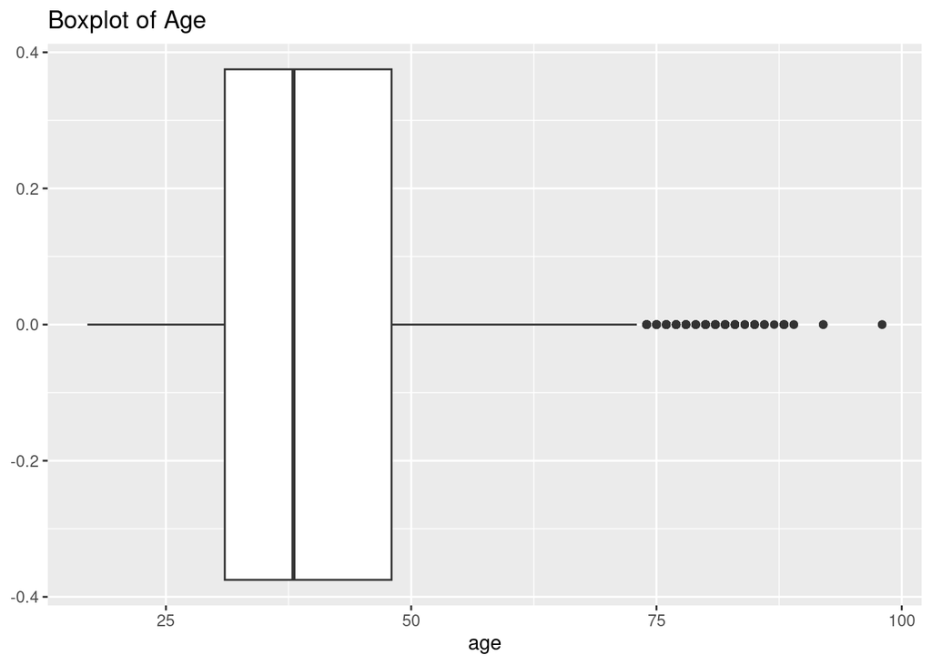

```r
# B boxplot
institution %>%
  ggplot() +
  geom_boxplot(aes(x=age)) +
  ggtitle('Boxplot of Age')
```

```r
# C deciles of variables
quantile(institution$age, seq(from = 0, to = 1, by = 0.20))
```

```
##   0%  20%  40%  60%  80% 100%
##   17   30   35   41   51   98
```

## 5.2 Duration

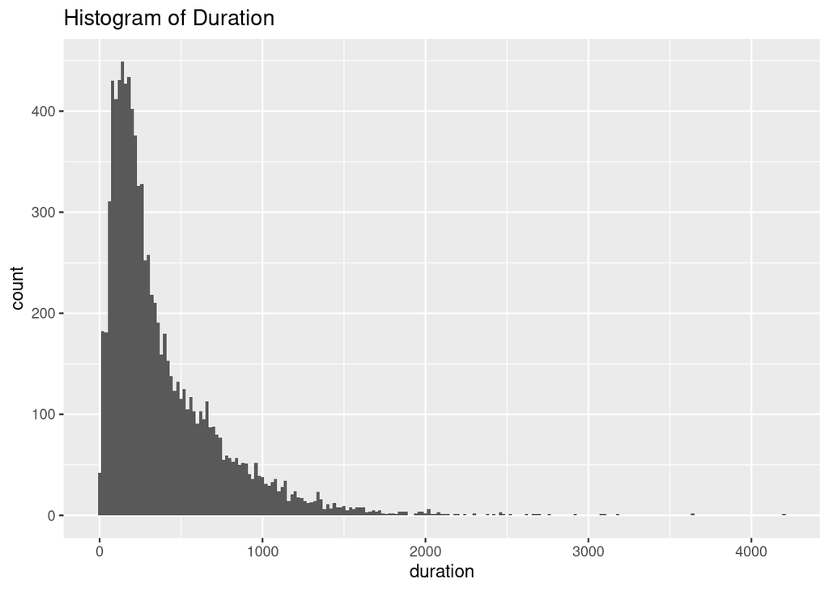

```r
# A histogram
institution %>% ggplot() +
  geom_histogram(aes(x=duration),binwidth = 20) +
  ggtitle("Histogram of Duration")
```

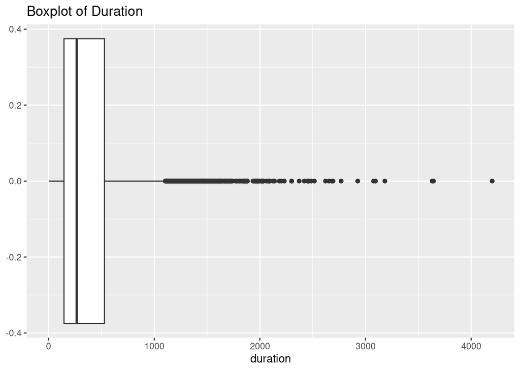

```r
# B boxplot
institution %>%
  ggplot() +
  geom_boxplot(aes(x=duration)) +
  ggtitle('Boxplot of Duration')
```

```r
# C deciles of variables
quantile(institution$duration, seq(from = 0, to = 1, by = 0.20))
```

```
##   0%  20%  40%  60%  80% 100%
##    1  124  211  340  615 4199
```

## 5.3 Campaign

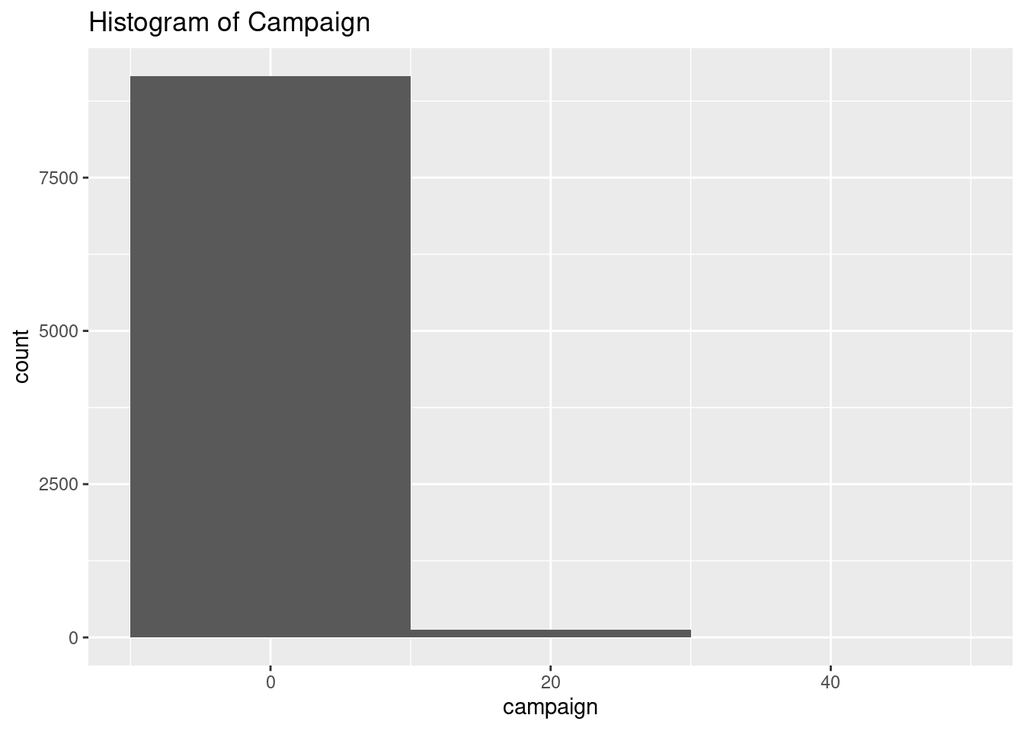

```r
# A histogram
institution %>% ggplot() +
  geom_histogram(aes(x=campaign),binwidth = 20) +
  ggtitle("Histogram of Campaign ")
```

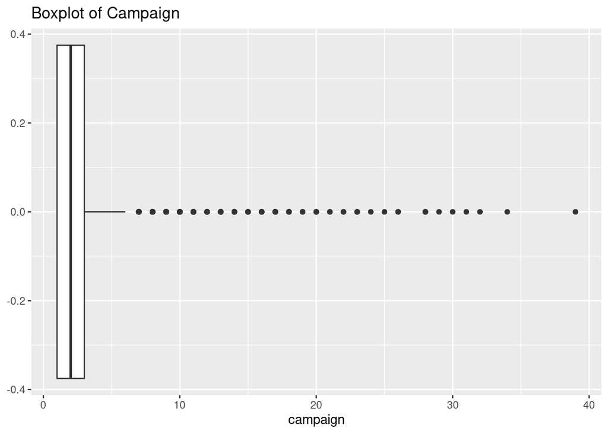

```r
# B boxplot
institution %>%
  ggplot() +
  geom_boxplot(aes(x=campaign)) +
  ggtitle('Boxplot of Campaign')
```

```r
# C deciles of variables
quantile(institution$campaign, seq(from = 0, to = 1, by = 0.20))
```

```
##   0%  20%  40%  60%  80% 100%
##    1    1    1    2    3   39
```

## 5.4 Pdays

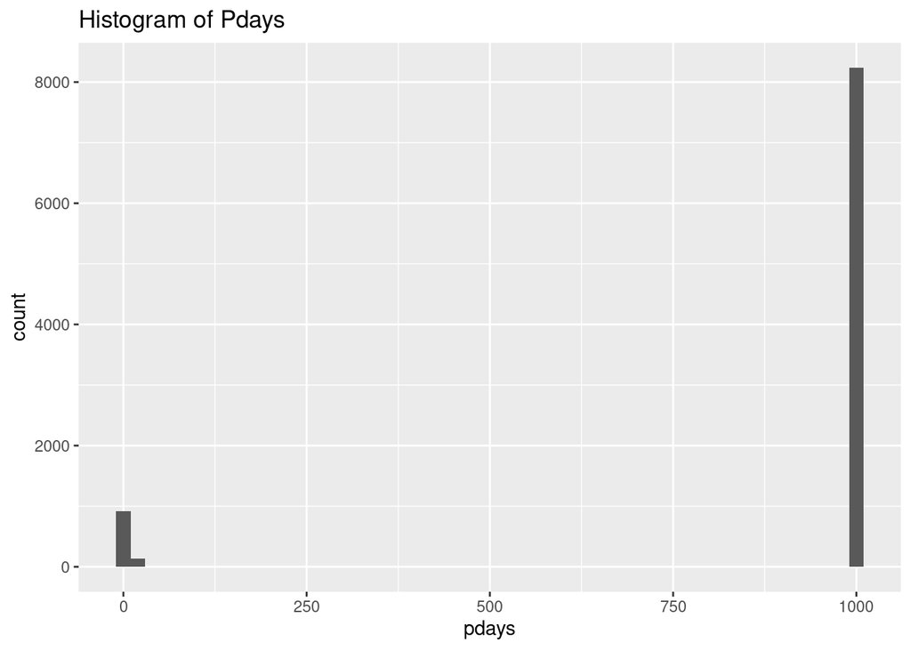

```r
# A histogram
institution %>% ggplot() +
  geom_histogram(aes(x=pdays),binwidth = 20) +
  ggtitle("Histogram of Pdays")
```

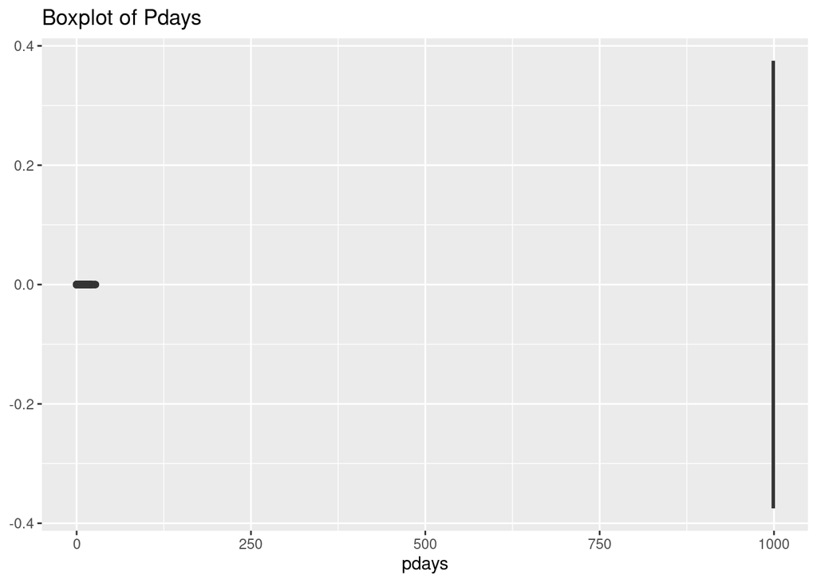

```r
# B boxplot
institution %>%
  ggplot() +
  geom_boxplot(aes(x=pdays)) +
  ggtitle('Boxplot of Pdays')
```

```r
# C deciles of variables
quantile(institution$pdays, seq(from = 0, to = 1, by = 0.20))
```

```
##   0%  20%  40%  60%  80% 100%
##    0  999  999  999  999  999
```

# 6 Task II code chunks 3

## 6.1 A

### 6.1.1 Count the value for y, job, education, poutcome

```r
# count y
institution %>% pull(y) %>% nlevels()
```

```
## [1] 2
```

```r
# count job
institution %>% pull(job) %>% nlevels()
```

```
## [1] 12
```

```r
# count education
institution %>% pull(education) %>% nlevels()
```

```
## [1] 8
```

```r
# count poutcome
institution %>% pull(poutcome) %>% nlevels()
```

```
## [1] 3
```

### 6.1.2 Calculate percentage value for y, job, education, poutcome

```r
# percentage for y
prop.table(table(institution$y))*100
```

```
##
##  no yes
##  50  50
```

```r
# percentage for job
prop.table(table(institution$job))*100
```

```
##
##        admin.   blue-collar  entrepreneur     housemaid    management
##     27.122845     19.062500      3.318966      2.327586      7.015086
##       retired self-employed      services       student    technician
##      6.411638      3.297414      8.329741      3.857759     15.721983
##    unemployed       unknown
##      2.672414      0.862069
```

```r
# percentage for Education
prop.table(table(institution$education))*100
```

```
##
##            basic.4y            basic.6y            basic.9y         high.school
##          9.64439655          4.93534483         12.68318966         22.65086207
##          illiterate professional.course   university.degree             unknown
##          0.06465517         12.82327586         32.40301724          4.79525862
```

```r
# percentage for Poutcome
prop.table(table(institution$poutcome))*100
```

```
##
##     failure nonexistent     success
##    11.57328    78.06034    10.36638
```

## 6.2 B

Bar plot

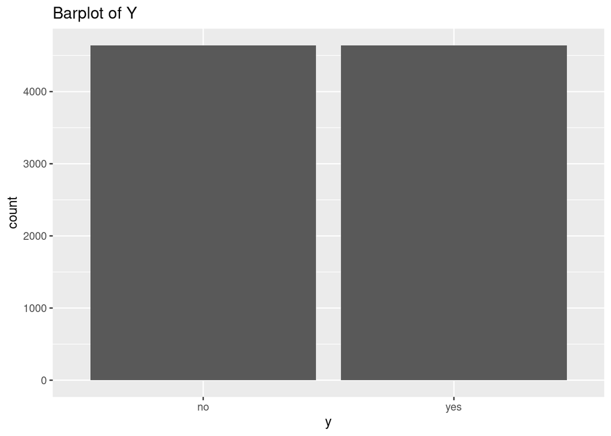

```r
# For variable y
institution %>% ggplot() +
  geom_bar(aes(x=y)) +
  ggtitle("Barplot of Y")
```

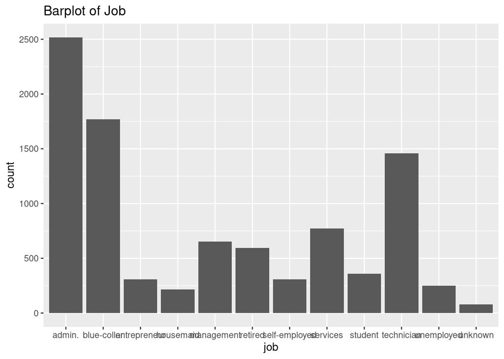

```r
# For variable job
institution %>% ggplot() +
  geom_bar(aes(x=job)) +
  ggtitle("Barplot of Job")
```

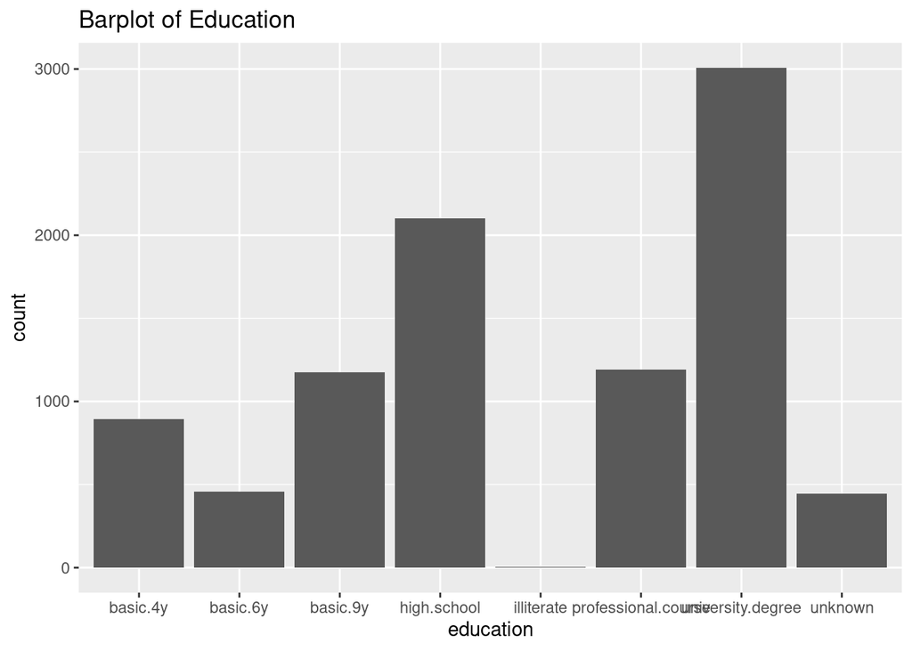

```r
# For variable education
institution %>% ggplot() +
  geom_bar(aes(x=education)) +
  ggtitle("Barplot of Education")
```

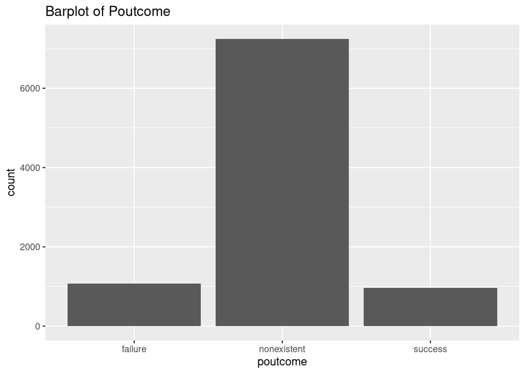

```r
# For the variable poutcome
institution %>% ggplot() +
  geom_bar(aes(x=poutcome)) +
  ggtitle("Barplot of Poutcome")
```

# 7 Task II Code Chunks 4

## 7.1 A

Use cor and pairs.panels to display correlations for these seven numeric variables – age, duration, campaign, pdays, euribor3m, emp.var.rate, and nr.employed.

```r
# correlations
institution %>% select(age, duration, campaign, pdays, euribor3m, emp.var.rate, nr.employed) %>% cor()
```

```
##                       age    duration     campaign       pdays   euribor3m
## age           1.000000000 -0.02072651  0.003690016 -0.05351616 -0.04462745
## duration     -0.020726510  1.00000000 -0.025872465  0.02893622  0.05733951
## campaign      0.003690016 -0.02587247  1.000000000  0.08930062  0.17512283
## pdays        -0.053516156  0.02893622  0.089300624  1.00000000  0.38773934
## euribor3m    -0.044627449  0.05733951  0.175122827  0.38773934  1.00000000
## emp.var.rate -0.049052629  0.07144035  0.185736186  0.33488799  0.95840218
## nr.employed  -0.074686516  0.05823209  0.176972215  0.47499217  0.94054583
##              emp.var.rate nr.employed
## age           -0.04905263 -0.07468652
## duration       0.07144035  0.05823209
## campaign       0.18573619  0.17697221
## pdays          0.33488799  0.47499217
## euribor3m      0.95840218  0.94054583
## emp.var.rate   1.00000000  0.86752989
## nr.employed    0.86752989  1.00000000
```

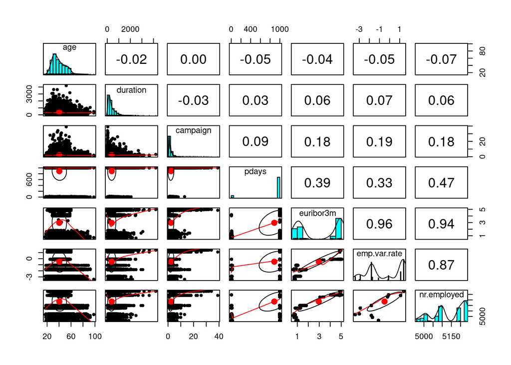

```r
# Pair Panels
institution %>% select(age, duration, campaign, pdays, euribor3m, emp.var.rate, nr.employed) %>% pairs.panels()
```

## 7.2 B

For each of these numeric variables - duration, emp.var.rate, cons.price.idx, and cons.conf.idx ### (i) (i) Show a boxplot of this numeric variable by y.

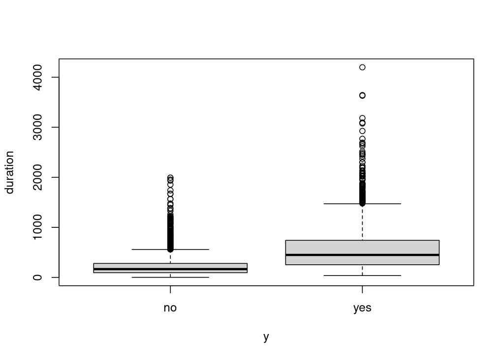

```r
boxplot(duration~y, data = institution)
```

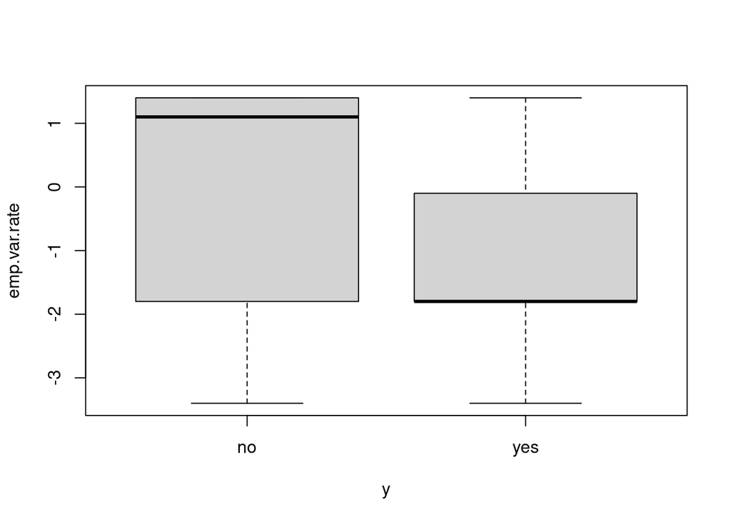

```r
boxplot(emp.var.rate~y, data = institution)
```

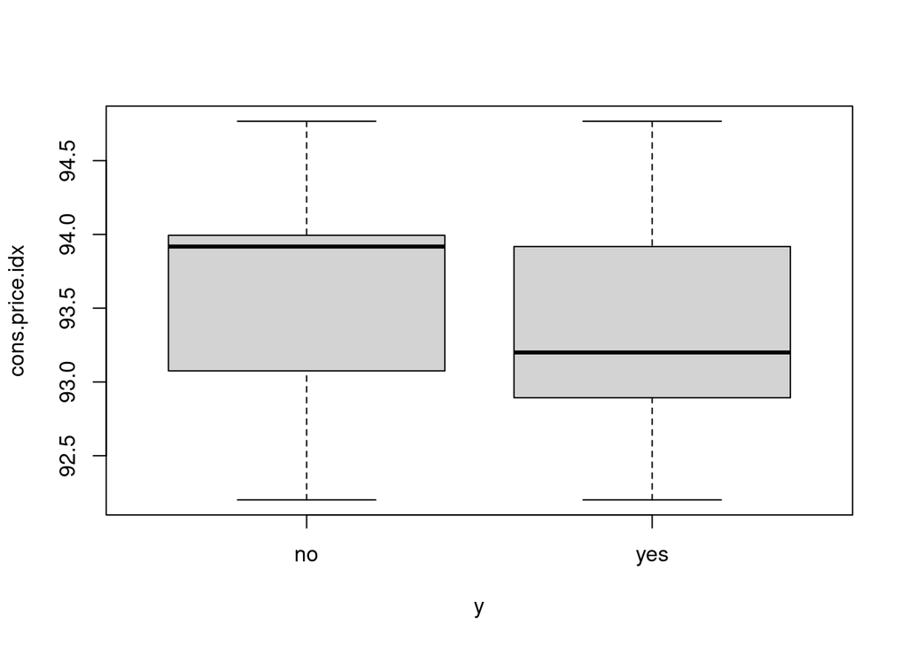

```r
boxplot(cons.price.idx~y, data = institution)
```

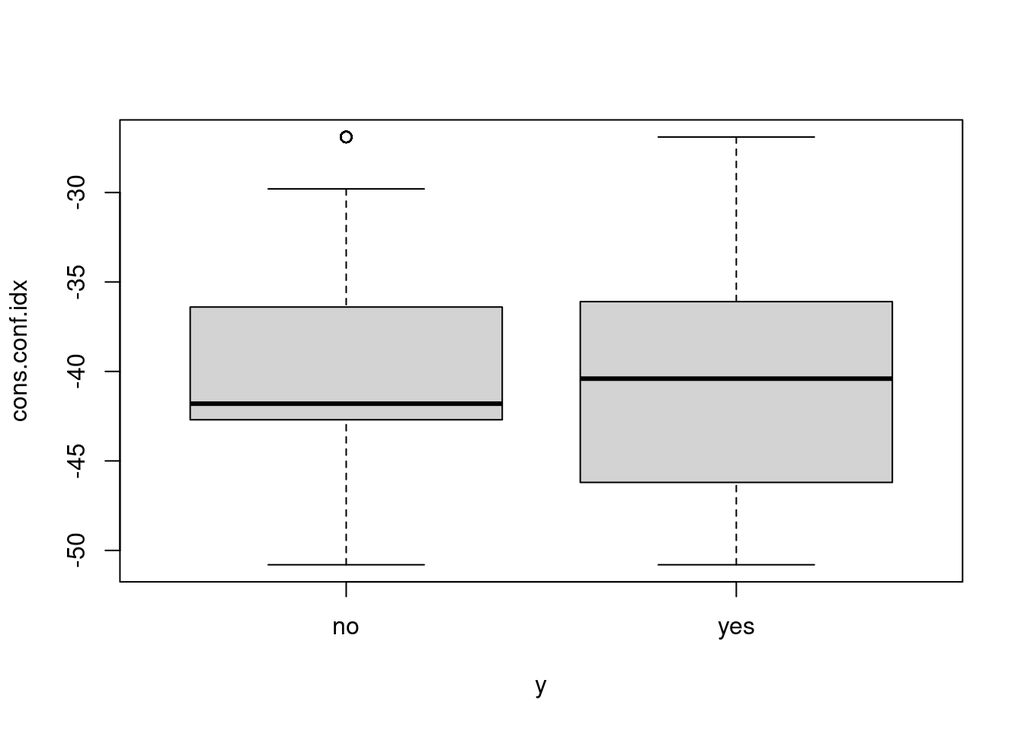

```r
boxplot(cons.conf.idx~y, data = institution)
```

### (ii) (ii) Use the aggregate function with ‘summary’ to aggregate this variable by y. The output should be the six number statistics (i.e. min., 1st quantile, median, mean, 3rd quantile, and max.) of the variable (e.g., duration)aggregated by “yes” and “no” respectively of y.

```r
# this will not show in output until Knit.

aggregate(duration~y, summary, data = institution) # duration
```

```
##     y duration.Min. duration.1st Qu. duration.Median duration.Mean
## 1  no        1.0000          94.0000        166.0000      221.5323
## 2 yes       37.0000         253.0000        449.0000      553.1912
##   duration.3rd Qu. duration.Max.
## 1         279.2500     1994.0000
## 2         741.2500     4199.0000
```

```r
aggregate(emp.var.rate~y, summary, data = institution) # emp.var.rate
```

```
##     y emp.var.rate.Min. emp.var.rate.1st Qu. emp.var.rate.Median
## 1  no        -3.4000000           -1.8000000           1.1000000
## 2 yes        -3.4000000           -1.8000000          -1.8000000
##   emp.var.rate.Mean emp.var.rate.3rd Qu. emp.var.rate.Max.
## 1         0.2409052            1.4000000         1.4000000
## 2        -1.2334483           -0.1000000         1.4000000
```

```r
aggregate(cons.price.idx~y, summary, data = institution) # cons.price.idx
```

```
##     y cons.price.idx.Min. cons.price.idx.1st Qu. cons.price.idx.Median
## 1  no            92.20100               93.07500              93.91800
## 2 yes            92.20100               92.89300              93.20000
##   cons.price.idx.Mean cons.price.idx.3rd Qu. cons.price.idx.Max.
## 1            93.60397               93.99400            94.76700
## 2            93.35439               93.91800            94.76700
```

```r
aggregate(cons.conf.idx~y, summary, data = institution) # cons.conf.idx
```

```
##     y cons.conf.idx.Min. cons.conf.idx.1st Qu. cons.conf.idx.Median
## 1  no          -50.80000             -42.70000            -41.80000
## 2 yes          -50.80000             -46.20000            -40.40000
##   cons.conf.idx.Mean cons.conf.idx.3rd Qu. cons.conf.idx.Max.
## 1          -40.64647             -36.40000          -26.90000
## 2          -39.78978             -36.10000          -26.90000
```

# 8 Task III

## 8.2 Columns of data:

### 8.2.1 Numeric Variables:

age: Age of the individual.

duration: Duration of the contact in seconds.

campaign: Number of contacts performed during this campaign.

pdays: Number of days that passed after the client was last contacted.

previous: Number of contacts performed before this campaign for this client.

emp.var.rate: Employment variation rate - quarterly indicator.

cons.price.idx: Consumer price index - monthly indicator.

cons.conf.idx: Consumer confidence index - monthly indicator.

euribor3m: Euribor 3 month rate - daily indicator.

nr.employed: Number of employees - quarterly indicator.

### 8.2.2 Categorical Variables:

job: Type of job.

marital: Marital status.

education: Education level.

default: Has credit in default? (yes/no).

housing: Has housing loan? (yes/no).

loan: Has personal loan? (yes/no).

contact: Contact communication type.

month: Last contact month of year.

day_of_week: Last contact day of the week.

poutcome: Outcome of the previous marketing campaign.

### 8.2.3 Target Variable:

y: Has the client subscribed to a certified term deposit? (yes/no).

## 8.3 Types of data within column:

Int(numeric) and Factor

## 8.4 Summary of Findings

The dataset includes a mix of numeric and categorical variables with varying distributions.

There are strong correlations between some economic indicators, such as nr.employed and emp.var.rate.

The target variable y (subscription to a term deposit) can potentially be predicted using variables such as duration, euribor3m, emp.var.rate, and nr.employed due to their distribution and correlations observed.

## 8.5 Interpretation

Duration is a critical variable, though it needs careful handling due to its post-contact nature.

Economic indicators like emp.var.rate, nr.employed, and euribor3m could be significant predictors for subscription likelihood.

Categorical variables like job, education, and poutcome provide useful segmentation of clients, impacting the predictive model’s accuracy.

The insights suggest that a combination of economic indicators, client demographics, and contact-related factors will be crucial in building a predictive model for term deposit subscriptions.